# STAT605 Project Report

# Spotify Popularity Insights: Top 5 Correlated Song Features Across Genres

**Members:**

1. Vaishnavi Borwankar
2. Niharika Chunduru
3. Osama Kheshaifaty
4. Sreeja Kodati
5. Kaiwalya Shukla

**GitHub Repository: [here](https://github.com/niharika-chunduru/STAT605-Project)**

# Introduction

The Spotify dataset, a compilation of over 278k songs from 6000 playlists is a comprehensive collection of song-related metadata sourced from the Spotify Platform. This dataset encapsulates a wide array of quantitative attributes and categorical genre classifications. Each entry includes essential song features such as loudness, tempo, danceability and more. The dataset, originally generated by the spotipy python library, also contains audio analysis of each song by its URI. The statistical question the project aims to answer is: Within each genre, what are the top five correlated features associated with song popularity based on track metadata.

# Data Description

The [6K Spotify Playlists](https://www.kaggle.com/datasets/viktoriiashkurenko/278k-spotify-songs/) dataset sourced from Kaggle contains metadata for 278k songs from over 6000 playlists, with a size of 60 GB. The data set consists of the following files:

- artists.csv
- final_tracks.csv
- final_playlists.csv
- main_dataset.csv
- music_genres.txt

Pre-processed audio analyses for each track are python dictionaries saved in separate pickle files which contain detailed features like loudness, beats, bars and segments. Genres were identified through the playlist data for playlists with more than 1k followers and are linked to respective tracks in the playlist. Different data sets for parallel processing were filtered by grouping tracks on the identified genre

# Statistical Computation

The project aimed to predict song popularity using Spotify’s data set. Initially, audio features’ correlation with popularity was calculated to identify key features. By sorting the correlation matrix, the top 5 features most correlated with popularity were selected for each model, ensuring a focused analysis to optimize model efficiency and accuracy.

Three models were employed:

1. **Linear Regression:** Although based on linear predictability, this model struggled to capture musical complexities, showing low R-squared (<0.15) and poor MSE results.

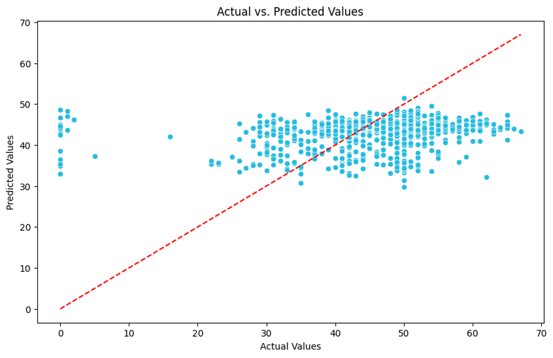

2. **MLP Regressor:** Utilized for discerning non-linear patterns, it showed limited fit for the dataset, particularly in Jazz (R-squared as low as 0.11).

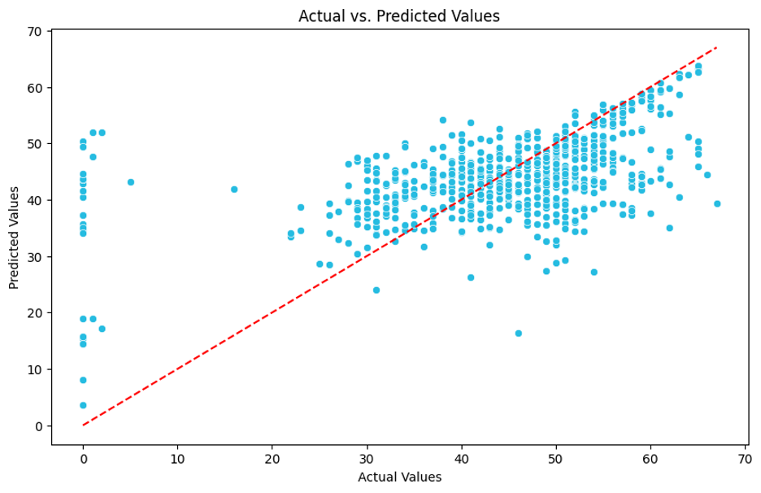

3. **Random Forest:** Despite being robust, it yielded low R-squared values (0.33), indicating weak predictive power.

[figure not shown]

# Parallel Computing

The correlation matrices are generated by executing Python scripts in parallel across genres. There were *30+* parallel jobs for the entire analysis. Each parallel job ran for approximately *17 mins*, and used memory and disk space of *800 MB* each.

- **HTCondor Job** - Iterates through each genre directory and allocates memory to each job to run the shell script.
- **Shell Script** - Assigns the run-time arguments according to the track genre and calls the analysis code.
- **Analysis Code** - Extracts the top correlated features for the popularity of a song from the track pickle files. Using the top five features, models are built to estimate the optimal MSE.

# Results

Coefficient plots track features are generated as outputs of the code. A few of them are show below. All plots can be found [here](https://github.com/niharika-chunduru/STAT605-Project/tree/main/output_plots).

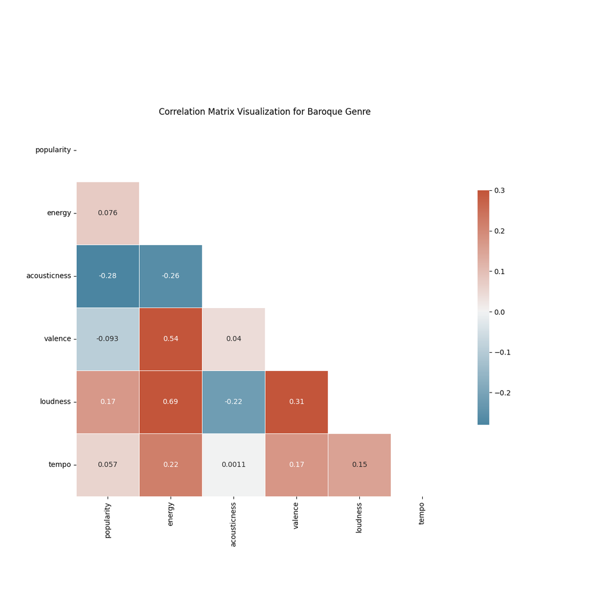

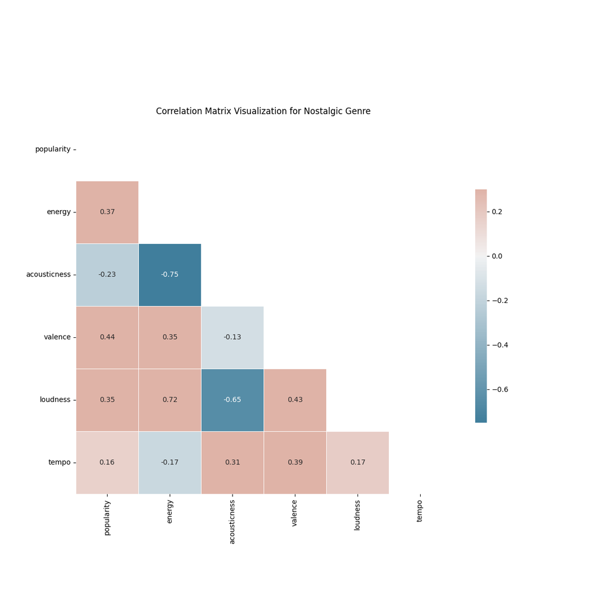

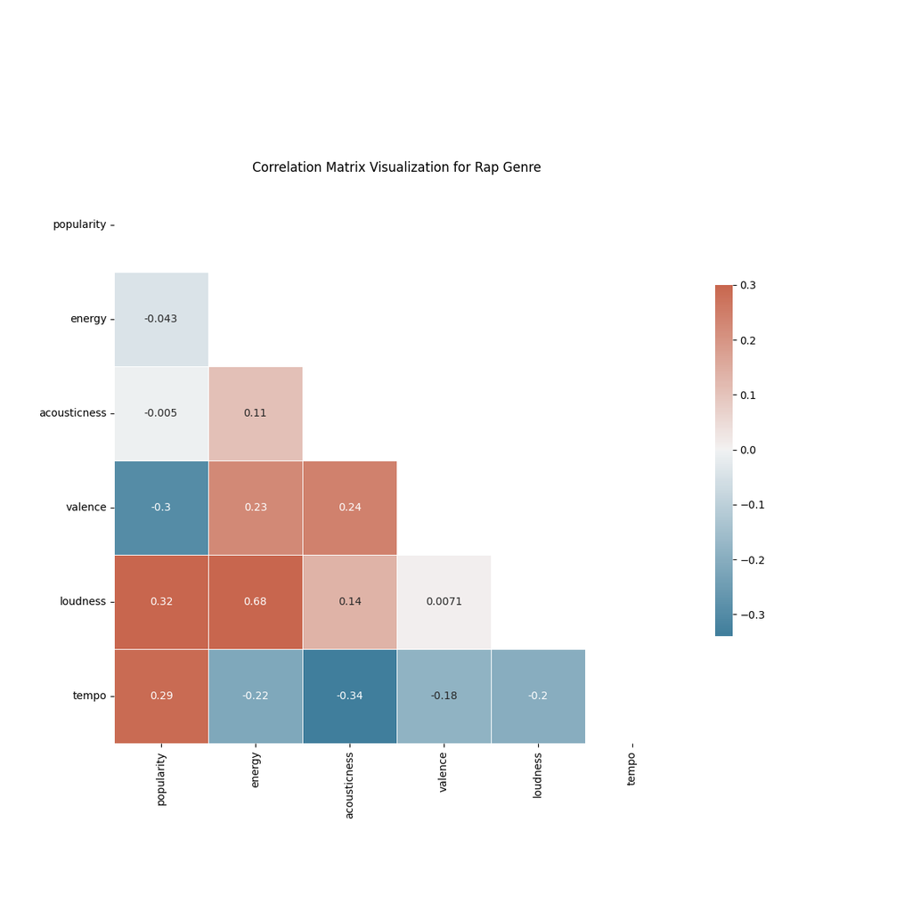

# Conclusion

In conclusion, this project made significant strides in exploring the correlation between audio features and song popularity in various genres, yet faced challenges in predicting popularity accurately. The analysis highlighted the complex nature of musical preferences and the difficulty in capturing them through quantitative features.

# Future Work

The analysis results could be presented differently on an interactive application that the target audience can use to get a summary for a specific genre. The correlation between the audio features and popularity must be interpreted non-technically to generate general suggestions. An interactive application that dynamically generates summaries for every genre can be done.

# Weakness

A primary limitation in this study is the weak correlation between identified audio features and song popularity within each genre, hindering accurate popularity predictions. Nevertheless, the analysis of individual feature correlations offers valuable insights into the characteristics of popular songs. This information could be particularly beneficial for target audiences and record business managers, providing them with specific data about popular music trends.

# Contributions

| Member | Proposal | Coding | Presentation | Report |
| --- | --- | --- | --- | --- |
| Niharika Chunduru | 0.5 | 1 | 1 | 0.2 |
| Vaishnavi Borwankar | 0.5 | 0.3 | 1 | 1 |